# Overview

Dataset info

| Number of variables | 9 |
| --- | --- |
| Number of observations | 907 |
| Total Missing (%) | 0.0% |
| Total size in memory | 57.7 KiB |
| Average record size in memory | 65.1 B |

Variables types

| Numeric | 5 |
| --- | --- |
| Categorical | 0 |
| Boolean | 1 |
| Date | 0 |
| Text (Unique) | 1 |
| Rejected | 2 |
| Unsupported | 0 |

Warnings

- `prcp` has 549 / 60.5% zeros Zeros
- `snow` has 877 / 96.7% zeros Zeros
- `snwd` has 861 / 94.9% zeros Zeros
- `tmax` is highly correlated with `tmid` (ρ = 0.98981) Rejected
- `tmid` is highly correlated with `tmin` (ρ = 0.98822) Rejected

# Variables

date  
Categorical, Unique

| First 3 values |
| --- |
| 2019-01-18 |
| 2018-10-22 |
| 2017-12-01 |

| Last 3 values |
| --- |
| 2018-09-20 |
| 2017-08-21 |
| 2019-03-03 |

Toggle details

First 10 values

| Value | Count | Frequency (%) |  |
| --- | --- | --- | --- |
| 2017-01-01 | 1 | 0.1% |  |
| 2017-01-02 | 1 | 0.1% |  |
| 2017-01-03 | 1 | 0.1% |  |
| 2017-01-04 | 1 | 0.1% |  |
| 2017-01-05 | 1 | 0.1% |  |

Last 10 values

| Value | Count | Frequency (%) |  |
| --- | --- | --- | --- |
| 2019-06-26 | 1 | 0.1% |  |
| 2019-06-27 | 1 | 0.1% |  |
| 2019-06-28 | 1 | 0.1% |  |
| 2019-06-29 | 1 | 0.1% |  |
| 2019-06-30 | 1 | 0.1% |  |

holiday  
Boolean

| Distinct count | 2 |
| --- | --- |
| Unique (%) | 0.2% |
| Missing (%) | 0.0% |
| Missing (n) | 0 |

| Mean | 0.029768 |
| --- | --- |

| True | 27 |
| --- | --- |
| (Missing) | 880 |

Toggle details

| Value | Count | Frequency (%) |  |
| --- | --- | --- | --- |
| True | 27 | 3.0% |  |
| (Missing) | 880 | 97.0% |  |

prcp  
Numeric

| Distinct count | 114 |
| --- | --- |
| Unique (%) | 12.6% |
| Missing (%) | 0.0% |
| Missing (n) | 0 |
| Infinite (%) | 0.0% |
| Infinite (n) | 0 |

| Mean | 0.14871 |
| --- | --- |
| Minimum | 0 |
| Maximum | 3.03 |
| Zeros (%) | 60.5% |

Toggle details

**Statistics**

Quantile statistics

| Minimum | 0 |
| --- | --- |
| 5-th percentile | 0 |
| Q1 | 0 |
| Median | 0 |
| Q3 | 0.09 |
| 95-th percentile | 0.85 |
| Maximum | 3.03 |
| Range | 3.03 |
| Interquartile range | 0.09 |

Descriptive statistics

| Standard deviation | 0.35766 |
| --- | --- |
| Coef of variation | 2.4051 |
| Kurtosis | 20.389 |
| Mean | 0.14871 |
| MAD | 0.21545 |
| Skewness | 3.9176 |
| Sum | 134.88 |
| Variance | 0.12792 |
| Memory size | 7.2 KiB |

**Histogram**

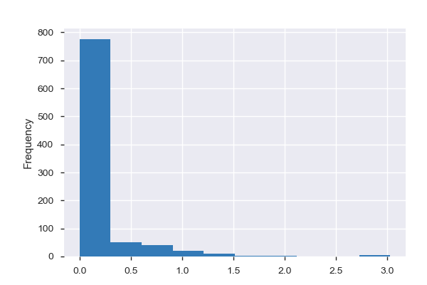

**Common Values**

| Value | Count | Frequency (%) |  |
| --- | --- | --- | --- |
| 0.0 | 549 | 60.5% |  |
| 0.01 | 33 | 3.6% |  |
| 0.03 | 19 | 2.1% |  |
| 0.06 | 18 | 2.0% |  |
| 0.02 | 17 | 1.9% |  |
| 0.1 | 13 | 1.4% |  |
| 0.04 | 13 | 1.4% |  |
| 0.05 | 12 | 1.3% |  |
| 0.08 | 11 | 1.2% |  |
| 0.11 | 10 | 1.1% |  |
| Other values (104) | 212 | 23.4% |  |

**Extreme Values**

Minimum 5 values

| Value | Count | Frequency (%) |  |
| --- | --- | --- | --- |
| 0.0 | 549 | 60.5% |  |
| 0.01 | 33 | 3.6% |  |
| 0.02 | 17 | 1.9% |  |
| 0.03 | 19 | 2.1% |  |
| 0.04 | 13 | 1.4% |  |

Maximum 5 values

| Value | Count | Frequency (%) |  |
| --- | --- | --- | --- |
| 2.24 | 1 | 0.1% |  |
| 2.82 | 1 | 0.1% |  |
| 2.9 | 1 | 0.1% |  |
| 3.02 | 1 | 0.1% |  |
| 3.03 | 1 | 0.1% |  |

rides  
Numeric

| Distinct count | 904 |
| --- | --- |
| Unique (%) | 99.7% |
| Missing (%) | 0.0% |
| Missing (n) | 0 |
| Infinite (%) | 0.0% |
| Infinite (n) | 0 |

| Mean | 47374 |
| --- | --- |
| Minimum | 1922 |
| Maximum | 85042 |
| Zeros (%) | 0.0% |

Toggle details

**Statistics**

Quantile statistics

| Minimum | 1922 |
| --- | --- |
| 5-th percentile | 15216 |
| Q1 | 32943 |
| Median | 49195 |
| Q3 | 63580 |
| 95-th percentile | 74507 |
| Maximum | 85042 |
| Range | 83120 |
| Interquartile range | 30636 |

Descriptive statistics

| Standard deviation | 19083 |
| --- | --- |
| Coef of variation | 0.40281 |
| Kurtosis | -0.89575 |
| Mean | 47374 |
| MAD | 16370 |
| Skewness | -0.26227 |
| Sum | 42968014 |
| Variance | 364150000 |
| Memory size | 7.2 KiB |

**Histogram**

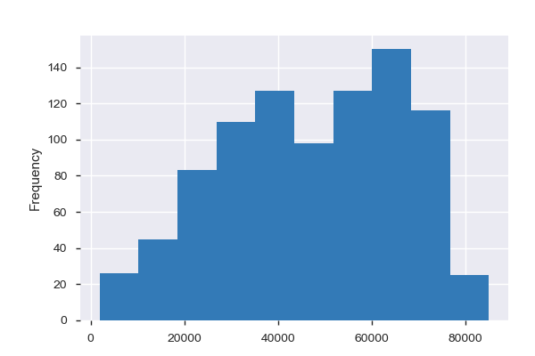

**Common Values**

| Value | Count | Frequency (%) |  |
| --- | --- | --- | --- |
| 36824 | 2 | 0.2% |  |
| 48612 | 2 | 0.2% |  |
| 41794 | 2 | 0.2% |  |
| 53247 | 1 | 0.1% |  |
| 62147 | 1 | 0.1% |  |
| 64217 | 1 | 0.1% |  |
| 37592 | 1 | 0.1% |  |
| 56023 | 1 | 0.1% |  |
| 60711 | 1 | 0.1% |  |
| 56434 | 1 | 0.1% |  |
| Other values (894) | 894 | 98.6% |  |

**Extreme Values**

Minimum 5 values

| Value | Count | Frequency (%) |  |
| --- | --- | --- | --- |
| 1922 | 1 | 0.1% |  |
| 1997 | 1 | 0.1% |  |
| 3755 | 1 | 0.1% |  |
| 4106 | 1 | 0.1% |  |
| 4295 | 1 | 0.1% |  |

Maximum 5 values

| Value | Count | Frequency (%) |  |
| --- | --- | --- | --- |
| 82950 | 1 | 0.1% |  |
| 83299 | 1 | 0.1% |  |
| 83301 | 1 | 0.1% |  |
| 83347 | 1 | 0.1% |  |
| 85042 | 1 | 0.1% |  |

snow  
Numeric

| Distinct count | 24 |
| --- | --- |
| Unique (%) | 2.6% |
| Missing (%) | 0.0% |
| Missing (n) | 0 |
| Infinite (%) | 0.0% |
| Infinite (n) | 0 |

| Mean | 0.078721 |
| --- | --- |
| Minimum | 0 |
| Maximum | 9.8 |
| Zeros (%) | 96.7% |

Toggle details

**Statistics**

Quantile statistics

| Minimum | 0 |
| --- | --- |
| 5-th percentile | 0 |
| Q1 | 0 |
| Median | 0 |
| Q3 | 0 |
| 95-th percentile | 0 |
| Maximum | 9.8 |
| Range | 9.8 |
| Interquartile range | 0 |

Descriptive statistics

| Standard deviation | 0.62335 |
| --- | --- |
| Coef of variation | 7.9185 |
| Kurtosis | 126.45 |
| Mean | 0.078721 |
| MAD | 0.15223 |
| Skewness | 10.542 |
| Sum | 71.4 |
| Variance | 0.38856 |
| Memory size | 7.2 KiB |

**Histogram**

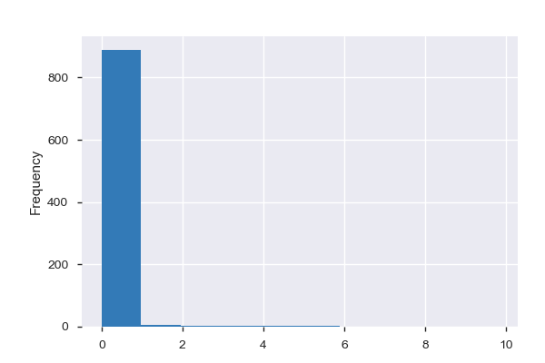

**Common Values**

| Value | Count | Frequency (%) |  |
| --- | --- | --- | --- |
| 0.0 | 877 | 96.7% |  |
| 1.2 | 4 | 0.4% |  |
| 0.5 | 2 | 0.2% |  |
| 0.1 | 2 | 0.2% |  |
| 0.2 | 2 | 0.2% |  |
| 0.4 | 2 | 0.2% |  |
| 4.6 | 1 | 0.1% |  |
| 5.1 | 1 | 0.1% |  |
| 1.0 | 1 | 0.1% |  |
| 4.4 | 1 | 0.1% |  |
| Other values (14) | 14 | 1.5% |  |

**Extreme Values**

Minimum 5 values

| Value | Count | Frequency (%) |  |
| --- | --- | --- | --- |
| 0.0 | 877 | 96.7% |  |
| 0.1 | 2 | 0.2% |  |
| 0.2 | 2 | 0.2% |  |
| 0.4 | 2 | 0.2% |  |
| 0.5 | 2 | 0.2% |  |

Maximum 5 values

| Value | Count | Frequency (%) |  |
| --- | --- | --- | --- |
| 5.1 | 1 | 0.1% |  |
| 5.5 | 1 | 0.1% |  |
| 6.4 | 1 | 0.1% |  |
| 8.2 | 1 | 0.1% |  |
| 9.8 | 1 | 0.1% |  |

snwd  
Numeric

| Distinct count | 9 |
| --- | --- |
| Unique (%) | 1.0% |
| Missing (%) | 0.0% |
| Missing (n) | 0 |
| Infinite (%) | 0.0% |
| Infinite (n) | 0 |

| Mean | 0.15226 |
| --- | --- |
| Minimum | 0 |
| Maximum | 7.9 |
| Zeros (%) | 94.9% |

Toggle details

**Statistics**

Quantile statistics

| Minimum | 0 |
| --- | --- |
| 5-th percentile | 0 |
| Q1 | 0 |
| Median | 0 |
| Q3 | 0 |
| 95-th percentile | 0.84 |
| Maximum | 7.9 |
| Range | 7.9 |
| Interquartile range | 0 |

Descriptive statistics

| Standard deviation | 0.78282 |
| --- | --- |
| Coef of variation | 5.1413 |
| Kurtosis | 44.737 |
| Mean | 0.15226 |
| MAD | 0.28908 |
| Skewness | 6.3234 |
| Sum | 138.1 |
| Variance | 0.61281 |
| Memory size | 7.2 KiB |

**Histogram**

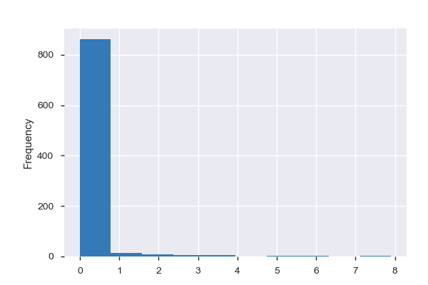

**Common Values**

| Value | Count | Frequency (%) |  |
| --- | --- | --- | --- |
| 0.0 | 861 | 94.9% |  |
| 1.2 | 15 | 1.7% |  |
| 2.0 | 8 | 0.9% |  |
| 3.1 | 7 | 0.8% |  |
| 3.9 | 7 | 0.8% |  |
| 5.1 | 4 | 0.4% |  |
| 5.9 | 2 | 0.2% |  |
| 7.9 | 2 | 0.2% |  |
| 7.1 | 1 | 0.1% |  |

**Extreme Values**

Minimum 5 values

| Value | Count | Frequency (%) |  |
| --- | --- | --- | --- |
| 0.0 | 861 | 94.9% |  |
| 1.2 | 15 | 1.7% |  |
| 2.0 | 8 | 0.9% |  |
| 3.1 | 7 | 0.8% |  |
| 3.9 | 7 | 0.8% |  |

Maximum 5 values

| Value | Count | Frequency (%) |  |
| --- | --- | --- | --- |
| 3.9 | 7 | 0.8% |  |
| 5.1 | 4 | 0.4% |  |
| 5.9 | 2 | 0.2% |  |
| 7.1 | 1 | 0.1% |  |
| 7.9 | 2 | 0.2% |  |

tmax  
Highly correlated

*This variable is highly correlated with `tmid` and should be ignored for analysis*

| Correlation | 0.98981 |
| --- | --- |

tmid  
Highly correlated

*This variable is highly correlated with `tmin` and should be ignored for analysis*

| Correlation | 0.98822 |
| --- | --- |

tmin  
Numeric

| Distinct count | 75 |
| --- | --- |
| Unique (%) | 8.3% |
| Missing (%) | 0.0% |
| Missing (n) | 0 |
| Infinite (%) | 0.0% |
| Infinite (n) | 0 |

| Mean | 48.235 |
| --- | --- |
| Minimum | 2 |
| Maximum | 81 |
| Zeros (%) | 0.0% |

Toggle details

**Statistics**

Quantile statistics

| Minimum | 2 |
| --- | --- |
| 5-th percentile | 21.3 |
| Q1 | 35 |
| Median | 48 |
| Q3 | 63 |
| 95-th percentile | 72 |
| Maximum | 81 |
| Range | 79 |
| Interquartile range | 28 |

Descriptive statistics

| Standard deviation | 16.762 |
| --- | --- |
| Coef of variation | 0.3475 |
| Kurtosis | -0.8892 |
| Mean | 48.235 |
| MAD | 14.43 |
| Skewness | -0.15471 |
| Sum | 43749 |
| Variance | 280.96 |
| Memory size | 7.2 KiB |

**Histogram**

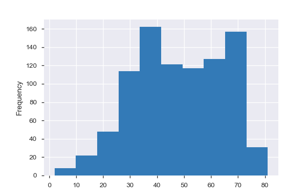

**Common Values**

| Value | Count | Frequency (%) |  |
| --- | --- | --- | --- |
| 39 | 26 | 2.9% |  |
| 69 | 25 | 2.8% |  |
| 68 | 25 | 2.8% |  |
| 56 | 24 | 2.6% |  |
| 37 | 24 | 2.6% |  |
| 32 | 23 | 2.5% |  |
| 33 | 23 | 2.5% |  |
| 35 | 23 | 2.5% |  |
| 34 | 22 | 2.4% |  |
| 71 | 22 | 2.4% |  |
| Other values (65) | 670 | 73.9% |  |

**Extreme Values**

Minimum 5 values

| Value | Count | Frequency (%) |  |
| --- | --- | --- | --- |
| 2 | 1 | 0.1% |  |
| 4 | 1 | 0.1% |  |
| 5 | 1 | 0.1% |  |
| 6 | 2 | 0.2% |  |
| 7 | 1 | 0.1% |  |

Maximum 5 values

| Value | Count | Frequency (%) |  |
| --- | --- | --- | --- |
| 76 | 7 | 0.8% |  |
| 77 | 9 | 1.0% |  |
| 78 | 1 | 0.1% |  |
| 79 | 3 | 0.3% |  |
| 81 | 1 | 0.1% |  |

# Correlations

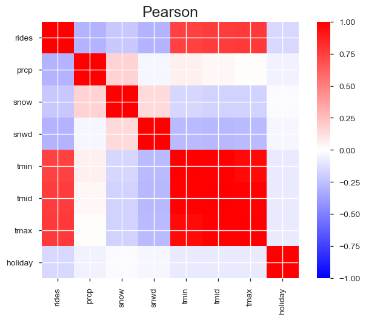

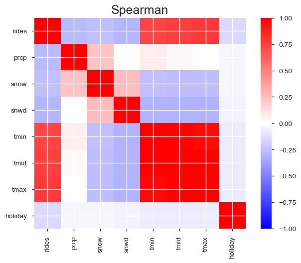

# Sample

|  | date | rides | prcp | snow | snwd | tmin | tmid | tmax | holiday |
| --- | --- | --- | --- | --- | --- | --- | --- | --- | --- |
| 0 | 2017-01-01 | 16009 | 0.00 | 0.0 | 0.0 | 40 | 44.0 | 48 | True |
| 1 | 2017-01-02 | 8921 | 0.21 | 0.0 | 0.0 | 37 | 39.0 | 41 | True |
| 2 | 2017-01-03 | 14198 | 0.58 | 0.0 | 0.0 | 39 | 41.0 | 43 | False |
| 3 | 2017-01-04 | 34039 | 0.00 | 0.0 | 0.0 | 34 | 43.0 | 52 | False |
| 4 | 2017-01-05 | 28393 | 0.00 | 0.0 | 0.0 | 27 | 30.5 | 34 | False |